Skip to content

# Image preference

- **Goal**: Show a standard workflow for working with complex multi-modal preference datasets, such as for image-generation preference.
- **Dataset**: tomg-group-umd/pixelprose, is a comprehensive dataset of over 16M (million) synthetically generated captions, leveraging cutting-edge vision-language models (Gemini 1.0 Pro Vision) for detailed and accurate descriptions.
- **Libraries**: datasets, sentence-transformers
- **Components**: TextField, ImageField, TextQuestion, LabelQuestion [VectorField](https://docs.argilla.io/dev/reference/argilla/settings/vectors/#rgvectorfield), [FloatMetadataProperty](https://docs.argilla.io/dev/reference/argilla/settings/metadata_property/?h=#rgfloatmetadataproperty)

## Getting started

### Deploy the Argilla server

If you already have deployed Argilla, you can skip this step. Otherwise, you can quickly deploy Argilla following this guide.

### Set up the environment

To complete this tutorial, you need to install the Argilla SDK and a few third-party libraries via `pip`.

```python
!pip install argilla
```

```python
!pip install "sentence-transformers~=3.0"
```

Let's make the required imports:

```python
import io
import os
import time

import argilla as rg
import requests
from PIL import Image
from datasets import load_dataset, Dataset
from sentence_transformers import SentenceTransformer
```

You also need to connect to the Argilla server using the `api_url` and `api_key`.

```python
# Replace api_url with your url if using Docker
# Replace api_key with your API key under "My Settings" in the UI
# Uncomment the last line and set your HF_TOKEN if your space is private
client = rg.Argilla(
    api_url="https://[your-owner-name]-[your_space_name].hf.space",
    api_key="[your-api-key]",
    # headers={"Authorization": f"Bearer {HF_TOKEN}"}
)
```

## Vibe check the dataset

We will take a look at [the dataset](https://huggingface.co/datasets/tomg-group-umd/pixelprose) to understand its structure and the types of data it contains. We can do this using [the embedded Hugging Face Dataset Viewer](https://huggingface.co/docs/hub/main/en/datasets-viewer-embed).

[interactive chart not shown]

## Configure and create the Argilla dataset

Now, we will need to configure the dataset. In the settings, we can specify the guidelines, fields, and questions. We will include a `TextField`, an `ImageField` corresponding to the `url` image column, and two additional `ImageField` fields representing the images we will generate based on the `original_caption` column from our dataset. Additionally, we will use a `LabelQuestion` and an optional `TextQuestion`, which will be used to collect the user's preference and the reason behind it. We will also be adding a `VectorField` to store the embeddings for the `original_caption` so that we can use semantic search and speed up our labeling process. Lastly, we will include two `FloatMetadataProperty` to store information from the `toxicity` and the `identity_attack` columns.

Note

Check this how-to guide to know more about configuring and creating a dataset.

```python
settings = rg.Settings(
    guidelines="The goal is to choose the image that best represents the caption.",
    fields=[
        rg.TextField(
            name="caption",
            title="An image caption belonging to the original image.",
        ),
        rg.ImageField(
            name="image_original",
            title="The original image, belonging to the caption.",
        ),
        rg.ImageField(
            name="image_1",
            title="An image that has been generated based on the caption.",
        ),
        rg.ImageField(
            name="image_2",
            title="An image that has been generated based on the caption.",
        ),
    ],
    questions=[
        rg.LabelQuestion(
            name="preference",
            title="The chosen preference for the generation.",
            labels=["image_1", "image_2"],
        ),
        rg.TextQuestion(
            name="comment",
            title="Any additional comments.",
            required=False,
        ),
    ],
    metadata=[
        rg.FloatMetadataProperty(name="toxicity", title="Toxicity score"),
        rg.FloatMetadataProperty(name="identity_attack", title="Identity attack score"),

    ],
    vectors=[
        rg.VectorField(name="original_caption_vector", dimensions=384),
    ]
)
```

Let's create the dataset with the name and the defined settings:

```python
dataset = rg.Dataset(
    name="image_preference_dataset",
    settings=settings,
)
dataset.create()
```

## Add records

Even if we have created the dataset, it still lacks the information to be annotated (you can check it in the UI). We will use the `tomg-group-umd/pixelprose` dataset from [the Hugging Face Hub](https://huggingface.co/datasets/tomg-group-umd/pixelprose). Specifically, we will use `25` examples. Because we are dealing with a potentially large image dataset, we will set `streaming=True` to avoid loading the entire dataset into memory and iterate over the data to lazily load it.

Tip

When working with Hugging Face datasets, you can set `Image(decode=False)` so that we can get [public image URLs](https://huggingface.co/docs/datasets/en/image_load#local-files), but this depends on the dataset.

```python
n_rows = 25

hf_dataset = load_dataset("tomg-group-umd/pixelprose", streaming=True)
dataset_rows = [row for _,row in zip(range(n_rows), hf_dataset["train"])]
hf_dataset = Dataset.from_list(dataset_rows)

hf_dataset
```

```
Dataset({
    features: ['uid', 'url', 'key', 'status', 'original_caption', 'vlm_model', 'vlm_caption', 'toxicity', 'severe_toxicity', 'obscene', 'identity_attack', 'insult', 'threat', 'sexual_explicit', 'watermark_class_id', 'watermark_class_score', 'aesthetic_score', 'error_message', 'width', 'height', 'ori…
    num_rows: 25
})
```

Let's have a look at the first entry in the dataset.

```python
hf_dataset[0]
```

```
{'uid': '0065a9b1cb4da4696f2cd6640e00304257cafd97c0064d4c61e44760bf0fa31c',
 'url': 'https://media.gettyimages.com/photos/plate-of-food-from-murray-bros-caddy-shack-at-the-world-golf-hall-of-picture-id916117812?s=612x612',
 'key': '007740026',
 'status': 'success',
 'original_caption': 'A plate of food from Murray Bros Caddy Shack at the World Golf Hall of Fame',
 'vlm_model': 'gemini-pro-vision',
 'vlm_caption': ' This image displays: A plate of fried calamari with a lemon wedge and a side of green beans, served in a basket with a pink bowl of marinara sauce. The basket is sitting on a table with a checkered tablecloth. In the background is a glass of water and a plate with a burger and frie…
 'toxicity': 0.0005555678508244455,
 'severe_toxicity': 1.7323875454167137e-06,
 'obscene': 3.8304504414554685e-05,
 'identity_attack': 0.00010549413127591833,
 'insult': 0.00014773994917050004,
 'threat': 2.5982120860135183e-05,
 'sexual_explicit': 2.0972733182134107e-05,
 'watermark_class_id': 1.0,
 'watermark_class_score': 0.733799934387207,
 'aesthetic_score': 5.390625,
 'error_message': None,
 'width': 612,
 'height': 408,
 'original_width': 612,
 'original_height': 408,
 'exif': '{"Image ImageDescription": "A plate of food from Murray Bros. Caddy Shack at the World Golf Hall of Fame. (Photo by: Jeffrey Greenberg/Universal Images Group via Getty Images)", "Image XResolution": "300", "Image YResolution": "300"}',
 'sha256': '0065a9b1cb4da4696f2cd6640e00304257cafd97c0064d4c61e44760bf0fa31c',
 'image_id': 'null',
 'author': 'null',
 'subreddit': -1,
 'score': -1}
```

As we can see, the `url` column does not contain an image extension, so we will apply some additional filtering to ensure we have only public image URLs.

```python
hf_dataset = hf_dataset.filter(
    lambda x: any([x["url"].endswith(extension) for extension in [".jpg", ".png", ".jpeg"]]))

hf_dataset
```

```
Dataset({
    features: ['uid', 'url', 'key', 'status', 'original_caption', 'vlm_model', 'vlm_caption', 'toxicity', 'severe_toxicity', 'obscene', 'identity_attack', 'insult', 'threat', 'sexual_explicit', 'watermark_class_id', 'watermark_class_score', 'aesthetic_score', 'error_message', 'width', 'height', 'ori…
    num_rows: 18
})
```

### Generate images

We'll start by generating images based on the `original_caption` column using the recently released black-forest-labs/FLUX.1-schnell model. For this, we will use the free but rate-limited Inference API provided by Hugging Face, but you can use any other [model from the Hub](https://huggingface.co/models?inference=warm&pipeline_tag=text-to-image&sort=trending) or method. We will generate 2 images per example. Additionally, we will add a small retry mechanism to handle the rate limit.

Let's begin by defining and testing a generation function.

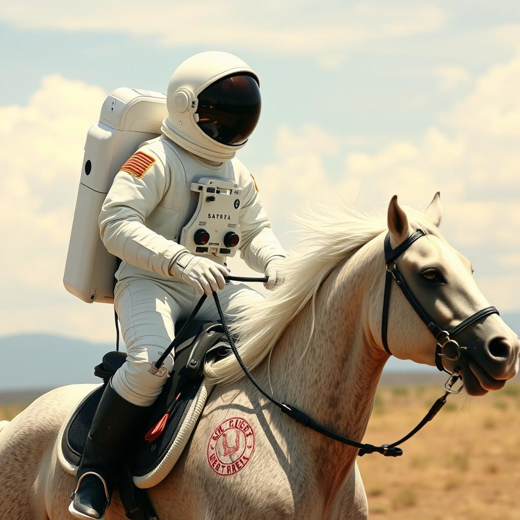

```python
API_URL = "https://api-inference.huggingface.co/models/black-forest-labs/FLUX.1-schnell"
headers = {"Authorization": f"Bearer {os.getenv('HF_TOKEN')}"}

def query(payload):
    response = requests.post(API_URL, headers=headers, json=payload)
    if response.status_code == 200:
        image_bytes = response.content
        image = Image.open(io.BytesIO(image_bytes))
    else:
        print(f"Request failed with status code {response.status_code}. retrying in 10 seconds.")
        time.sleep(10)
        image = query(payload)
    return image

query({
    "inputs": "Astronaut riding a horse"
})
```

Cool! Since we've evaluated the generation function, let's generate the PIL images for the dataset.

```python
def generate_image(row):
    caption = row["original_caption"]
    row["image_1"] = query({"inputs": caption})
    row["image_2"] = query({"inputs": caption + " "}) # space to avoid caching and getting the same image
    return row

hf_dataset_with_images = hf_dataset.map(generate_image, batched=False)

hf_dataset_with_images
```

```
Dataset({
    features: ['uid', 'url', 'key', 'status', 'original_caption', 'vlm_model', 'vlm_caption', 'toxicity', 'severe_toxicity', 'obscene', 'identity_attack', 'insult', 'threat', 'sexual_explicit', 'watermark_class_id', 'watermark_class_score', 'aesthetic_score', 'error_message', 'width', 'height', 'ori…
    num_rows: 18
})
```

### Add vectors

We will use the `sentence-transformers` library to create vectors for the `original_caption`. We will use the `TaylorAI/bge-micro-v2` model, which strikes a good balance between speed and performance. Note that we also need to convert the vectors to a `list` to store them in the Argilla dataset.

```python
model = SentenceTransformer("TaylorAI/bge-micro-v2")

def encode_questions(batch):
    vectors_as_numpy = model.encode(batch["original_caption"])
    batch["original_caption_vector"] = [x.tolist() for x in vectors_as_numpy]
    return batch

hf_dataset_with_images_vectors = hf_dataset_with_images.map(encode_questions, batched=True)
```

### Log to Argilla

We will easily add them to the dataset using `log` and the mapping, where we indicate which column from our dataset needs to be mapped to which Argilla resource if the names do not correspond. We are also using the `key` column as `id` for our record so we can easily backtrack the record to the external data source.

```python
dataset.records.log(records=hf_dataset_with_images_vectors, mapping={
    "key": "id",
    "original_caption": "caption",
    "url": "image_original",
})
```

Voilà! We have our Argilla dataset ready for annotation.

## Evaluate with Argilla

Now, we can start the annotation process. Just open the dataset in the Argilla UI and start annotating the records.

Note

Check this how-to guide to know more about annotating in the UI.

## Conclusions

In this tutorial, we present an end-to-end example of an image preference task. This serves as the base, but it can be performed iteratively and seamlessly integrated into your workflow to ensure high-quality curation of your data and improved results.

We started by configuring the dataset and adding records with the original and generated images. After the annotation process, you can evaluate the results and potentially retrain the model to improve the quality of the generated images.

Was this page helpful?